# DIFFERENTIAL EXPRESSION ANALYSIS

### **INTRODUCTION**

Quality control, processing, and alignment of raw RNA sequencing data from 12 samples were done, followed by differential expression analysis. The samples are raw sequencing reads from chromosome 2 of the mouse genome generated by the NextSeq500 sequencer and were prepared in four batches, each representing a biological replicate. They were categorized into three groups (A, B, and C) for comparative analysis.

### **METHOD**

The quality encoding of the raw FASTQ files was determined to be Phred+33 (Sanger format) through ASCII code analysis and comparing them to known quality encoding schemes.

The following tools and flags were used for raw data preprocessing:

#### **Adapter trimming with Scythe**

The **-q sanger** flag was chosen for Phred+33 quality encoding, and **-a ${adapter}** specified the adapter sequence to be removed. The output was saved as trim1.

#### **Quality trimming with Sickle**

The **-se** flag for single-end data, **-t sanger** for Phred+33 encoding, **-q 10** to set a minimum quality threshold of 10, and **-l 50** to remove reads shorter than 50 bases, which was appropriate given most samples had 75 base pairs in the first sequence.

#### **Alignment with HISAT2**

HISAT2 aligned reads to the reference genome. The **-p 4** flag enabled parallel processing, and **–phred33** indicated Phred+33 encoding. **-U** specified single-end reads for alignment.

#### **SAM to BAM conversion and sorting with Samtools**

The Samtools tool was used to convert the SAM file to BAM format.Temporary files were removed after processing.

#### **Transcript assembly with StringTie**

StringTie assembled transcripts and estimated gene expression. The **-p 4** flag enabled parallel processing, **-t** indicated transcriptomic data, **-e** enabled gene-level quantification, and **-B** created Ballgown-compatible output. The **-G** option specified the reference GTF file, and **-o** defined the output GTF file for each sample.

#### **Generation of expression matrix**

The prepDE.py script processed the list of GTF files to generate a gene expression matrix for differential expression analysis.

If paired-end reads were used, modifications would be necessary in the pipeline. In HISAT2, the **-U** flag for single-end reads would be replaced with **-1** and **-2** flags to indicate the paired-end read files. Similarly, Sickle would need to be run with the **-pe** flag to handle paired-end reads, and trimming would apply to both the forward and reverse read files.

### **RESULTS AND DISCUSSION**

The read statistics in **Table 1** and the distribution shown in **Figure 1** indicates high-quality sequencing data with minimal contamination rate (≤0.00034) across all samples. The majority of reads were retained after preprocessing, ensuring a strong dataset for downstream analysis. The alignment rate was 100%, with most reads aligning once, and a small portion aligning multiple times due to repetitive regions. These results indicate efficient preprocessing and alignment.

**Table 1 : showing read statistics for raw processed and aligned data**

| Sample | Total Reads | Contaminated Reads | Uncontaminated Reads | Contamination Rate | Reads Kept | Reads Discarded | Aligned 0 Times | Aligned Exactly 1 Time | Aligned >1 Times | Overall Alignment Rate |
| --- | --- | --- | --- | --- | --- | --- | --- | --- | --- | --- |
| s1.c2 | 5007025 | 1549 | 5005476 | 0.000309 | 5004437 | 2588 | 82 | 4469931 | 534424 | 100% |
| s2.c2 | 4788617 | 1612 | 4787005 | 0.000337 | 4784964 | 3653 | 114 | 4212383 | 572467 | 100% |
| s3.2 | 4271937 | 1448 | 4270489 | 0.000339 | 4270088 | 1849 | 78 | 3816738 | 453272 | 100% |
| s4.c2 | 4826596 | 1327 | 4825269 | 0.000275 | 4824954 | 1642 | 115 | 4261623 | 563216 | 100% |
| s5.c2 | 4509475 | 1353 | 4508122 | 0.000300 | 4506808 | 2667 | 94 | 3940251 | 566463 | 100% |
| s6.c2 | 4779843 | 1040 | 4778803 | 0.000218 | 4777339 | 2504 | 95 | 4174024 | 603220 | 100% |
| s7.c2 | 3741884 | 1051 | 3740833 | 0.000281 | 3740622 | 1262 | 97 | 3175295 | 565230 | 100% |
| s8.c2 | 7709668 | 2165 | 7707503 | 0.000281 | 7707368 | 2300 | 196 | 6547955 | 1159217 | 100% |
| s9.c2 | 5627869 | 1407 | 5626462 | 0.000250 | 5626056 | 1813 | 104 | 5004997 | 620955 | 100% |
| s10.c2 | 5955048 | 1632 | 5953416 | 0.000274 | 5952253 | 2795 | 113 | 5199092 | 753048 | 100% |
| s11.c2 | 5020636 | 1164 | 5019472 | 0.000232 | 5019101 | 1535 | 91 | 4478001 | 541009 | 100% |
| s12.c2 | 4236576 | 1179 | 4235397 | 0.000278 | 4235585 | 991 | 115 | 3695614 | 539856 | 100% |

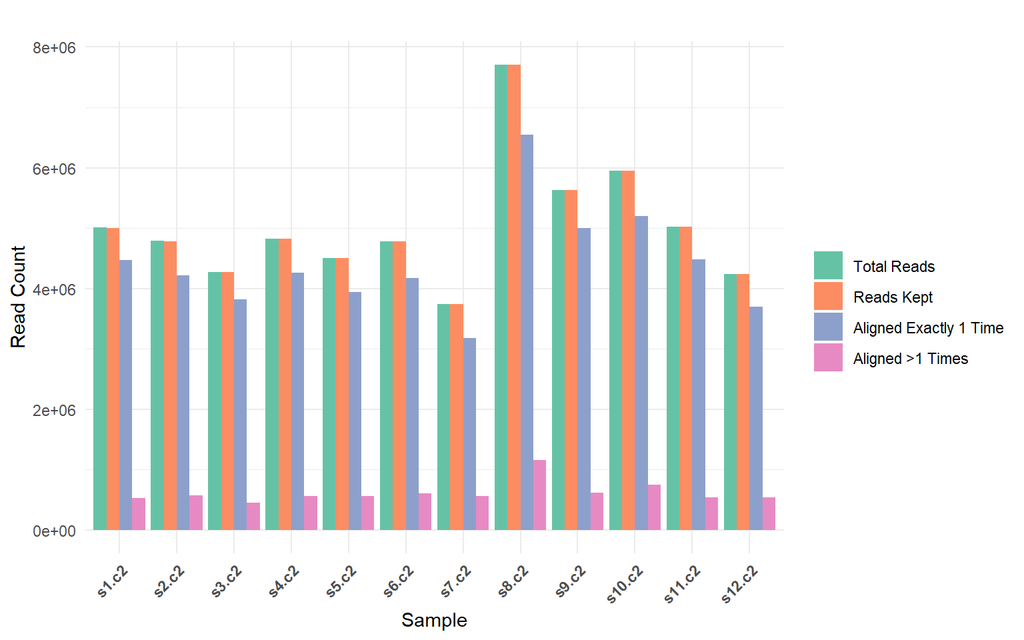

**Figure 1: Grouped bar plot showing read distribution across processing stages with each bar indicating number of reads.**

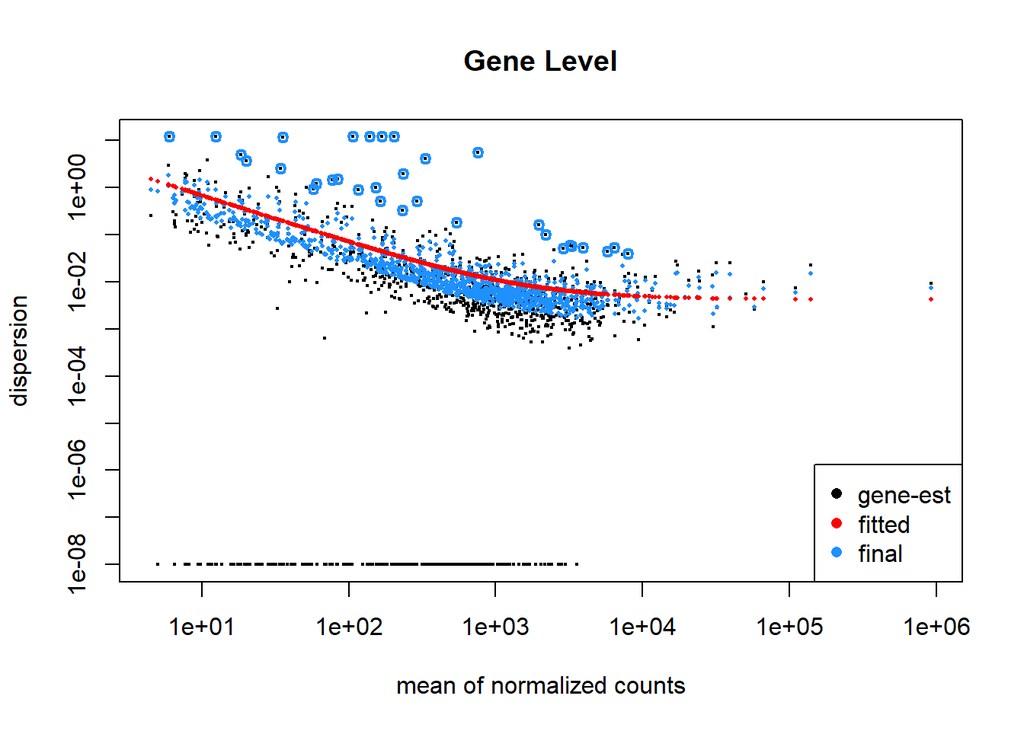

**(a)**

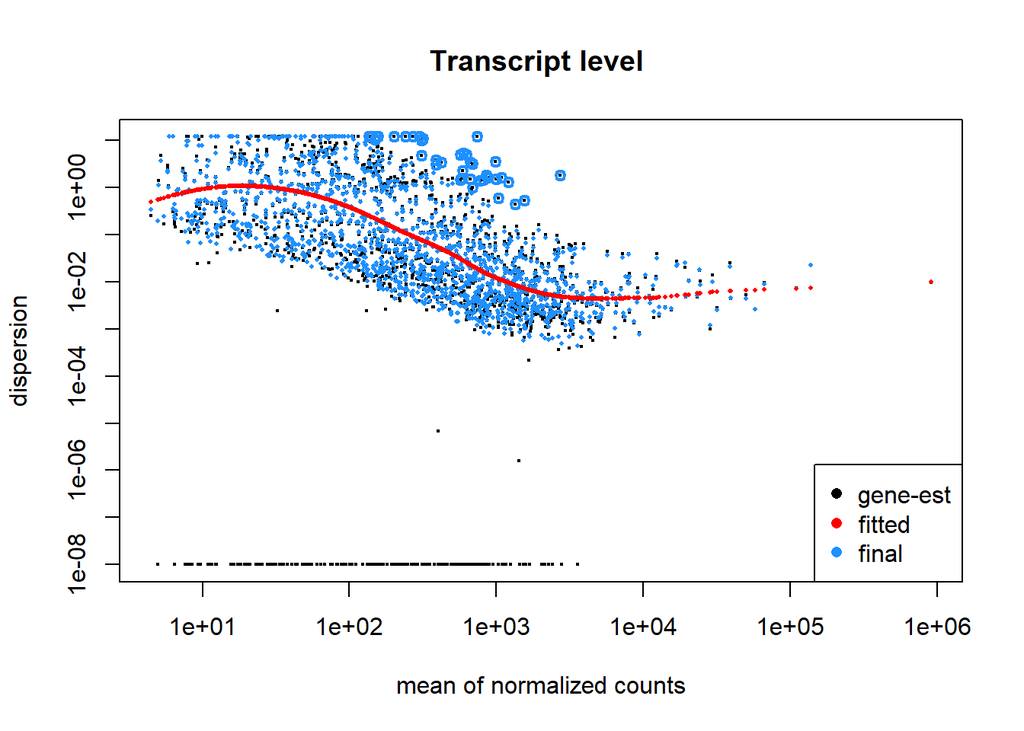

**(b)**

**Figure 2: Dispersion estimate plots for gene and transcript level data. (a) Gene level dispersion estimates. (b) Transcript level dispersion estimates.**

Dispersion plots **(Figure 2)** show how variance changes with mean expression. The red line represents expected dispersion, while blue dots show adjusted values after shrinkage. Gene-level data **(Figure 2a)** exhibit lower dispersion and less shrinkage than transcript-level data **(Figure 2b)** because gene expression averages signals from multiple transcript isoforms, reducing variability. In contrast, transcript-level expression is influenced by isoform (multiple transcripts of a gene) -specific factors like alternative splicing and regulation, leading to higher variability and a greater need for shrinkage to stabilize dispersion estimates.

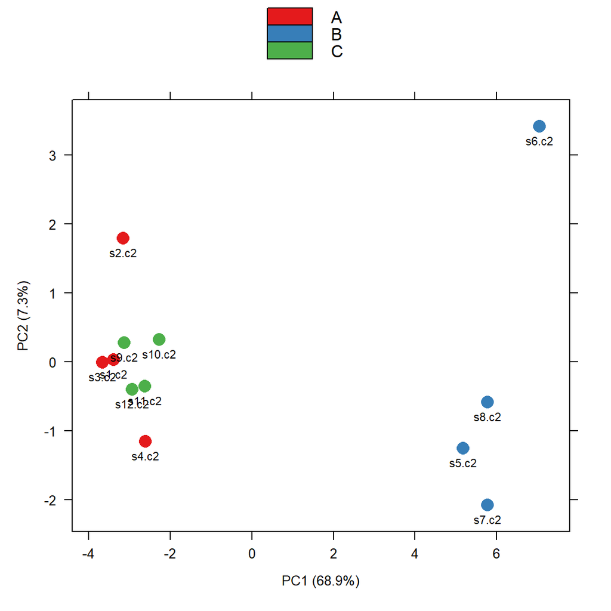

**Figure 3: PCA plot of rlog transformed values for gene level data showing clustering of samples with colouring based on groups**

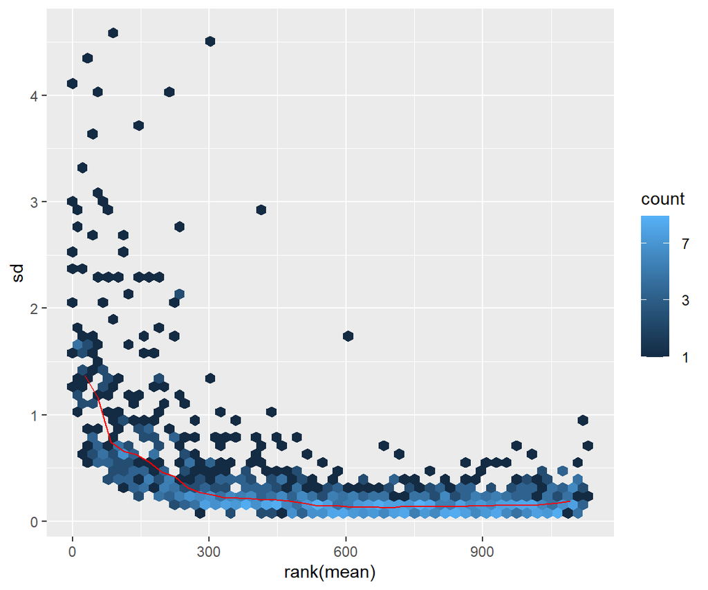

**(a)**

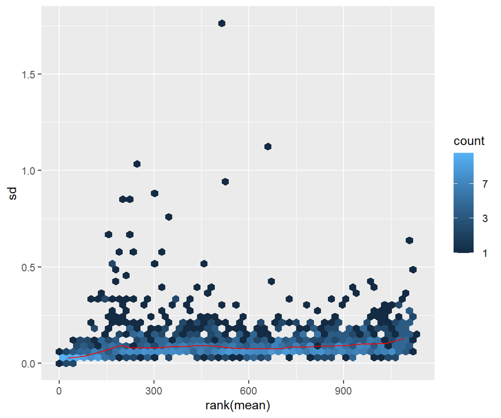

**(b)**

**Figure 4: SD versus Mean plots comparing the effect of rlog transformation on variance. (a) Plot showing the distribution of variance for log2(normalized counts). (b) Plot showing the distribution of variance for rlog-transformed counts, demonstrating improved homoscedasticity.**

The meanSD plots**(figure 4)** shows that regularised log(rlog) transfrmation **(figure 4b)** produce more homoscedastic data compared to log transformed data **(figure 4a)**. Homoscedasticity is essential to analyse the variance across gene expression .In log2-transformed data, standard deviation is higher at lower means, indicating greater variability. In contrast, rlog transformation stabilizes variance, as shown by the flattened trend line, ensuring more consistent standard deviation. Thus, rlog transformation is preferred over log2 transformation for downstream analysis.

In differential expression analysis, the null hypothesis of LFC = 0 assumes no change in gene expression between conditions, identifying genes with any statistically significant fold change. In contrast, the null hypothesis LFC < 1 applies a stricter threshold, considering only genes with a fold change greater than 2 (since LFC = log2(FC)), thus reducing the number of significant genes.

**Table 2 :Number of significant genes for B vs. A and C vs. A contrasts under different LFC hypotheses.**

| Contrast | LFC Hypothesis | Unshrunk LFC | shrunk LFC |
| --- | --- | --- | --- |
| B vs A | LFC = 0 | 511 | 511 |
| B vs A | LFC < 1 | 48 | 48 |
| C vs A | LFC = 0 | 38 | 38 |
| C vs A | LFC < 1 | 4 | 4 |

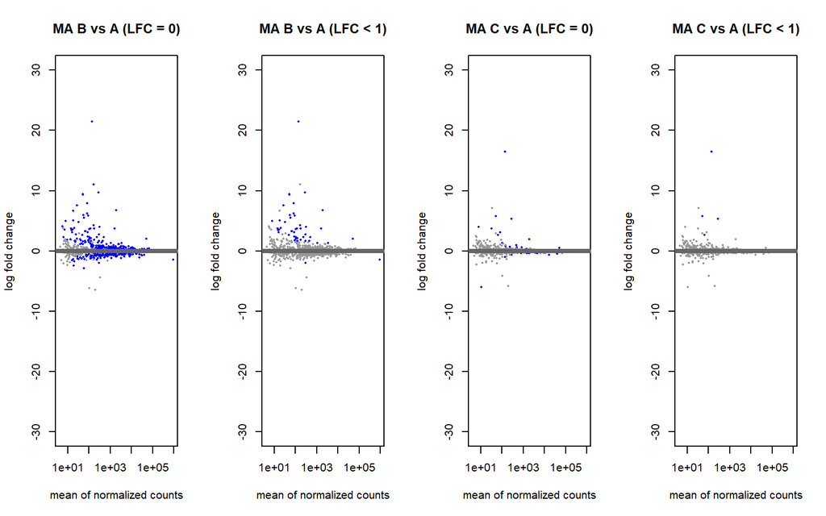

**(a)**

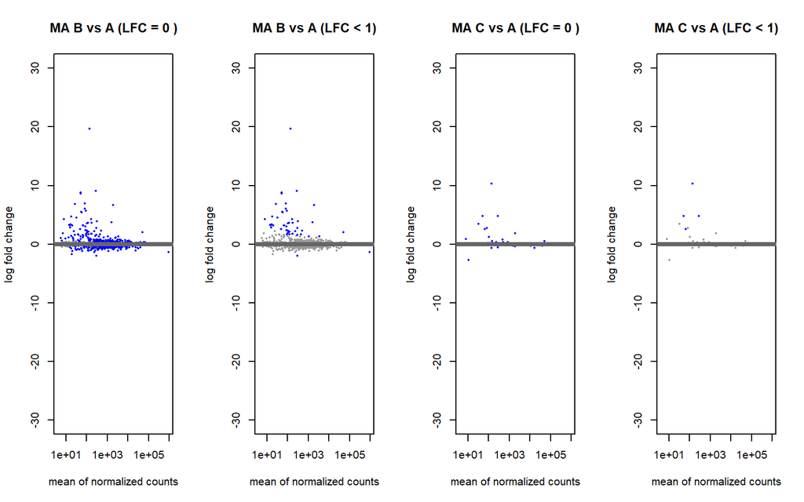

**(b)**

**Figure 5: MA plots for different contrasts (B vs. A and C vs. A) under different null hypotheses ( standard NULL hypothesis (LFC = 0) and LFC < 1) for unshrunken and shrunken LFC, with significant genes highlighted in blue. (a) MA plots for unshrunken LFC, showing fewer significant genes under LFC < 1 compared to LFC = 0, with points more widely spread along the trend line. (b) MA plots for shrunken LFC, showing fewer significant genes under LFC 1 but reduce noise along the trend line due to the stabilization effect of LFC shrinkage and adjusted extreme fold changes.**

As shown in **Table 2**, the number of significant genes is lower under LFC < 1 for both shrunken and unshrunken LFC, as many genes with smaller fold changes are excluded. After LFC shrinkage, the number of significant genes remains the same for both null hypotheses, suggesting that shrinkage stabilizes LFC estimates while maintaining statistical significance. The associated MA plots **(Figure 5)** illustrate this effect, where fewer genes are highlighted in blue under LFC < 1.

LFC shrinkage is applied to stabilize the fold change estimates, especially for genes with extreme values that could be driven by noise or small sample sizes. Shrunken LFC MA plots **(Figure 5b)** show reduced noise and a more stable distribution along the fitted line compared to unshrunk LFC MA plots **(Figure 5a)**, highlighting the stabilizing effect of LFC shrinkage. The LFC shrinkage method pulls extreme values closer to zero, making fold changes more reliable.LFC shrinkage ensures more robust and biologically meaningful results by reducing the impact of outliers.

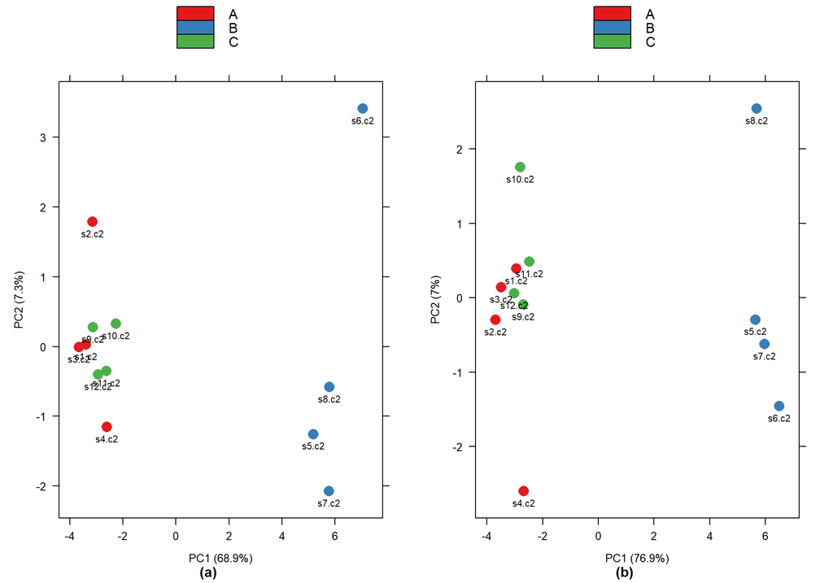

**Figure 6 : PCA ( Principal Component Analysis) plots demonstrating batch effect removal on gene level data coloured by groups ( A,B and C). (a) PCA plot without batch effect removal on rlog transformed gene level data showing PC1 68.9 % and PC2 7.3%. (b) PCA plot with with batch effect removal using limma on rlog transformed gene level data showing PC1 76.9% and PC2 7%**

After batch correction using limma, the PCA plots **(Figure 6)** show an increase in variation explained by PC1 (76.9% in **Figure 6b** compared to 68.9% in **Figure 6a**). This suggests that batch correction has successfully emphasized the biological differences between the groups. The persistent clustering of samples in groups A and C, evident in both PCA before and after correction, may indicate a greater similarity in gene expression between these groups. The samples s4.c2, s10.c2, and s8.c2 exhibit distinct separation from other samples after batch correction, highlighting their unique expression profiles.